# Wavelet Analysis

Jeffrey D Walker, PhD

August 18, 2014

This document describes how to perform a wavelet analysis of an annual precipitation timeseries. Three identical analyses are performed using 1) Scott Steinshneider’s code, and 2) the `biwavelet` package, and 3) the `weatherGen` package.

## Load Data

```r
library(dplyr)
library(tidyr)
library(lubridate)
library(ggplot2)
theme_set(theme_bw())
library(weatherGen)
data(climate)

# compute daily averages across sites
clim.da <- group_by(climate, DATE) %>%
  summarise(N=n(),
            PRCP=mean(PRCP),
            TMIN=mean(TMIN),
            TMAX=mean(TMAX))

# aggregate by water year
clim.wyr <- clim.da %>%
  mutate(WYEAR=wyear(DATE)) %>%
  group_by(WYEAR) %>%
  summarise(N=n(),
            PRCP=sum(PRCP),
            TMIN=mean(TMIN),
            TMAX=mean(TMAX))
```

Here is a timeseries plot of the annual precipitation timeseries.

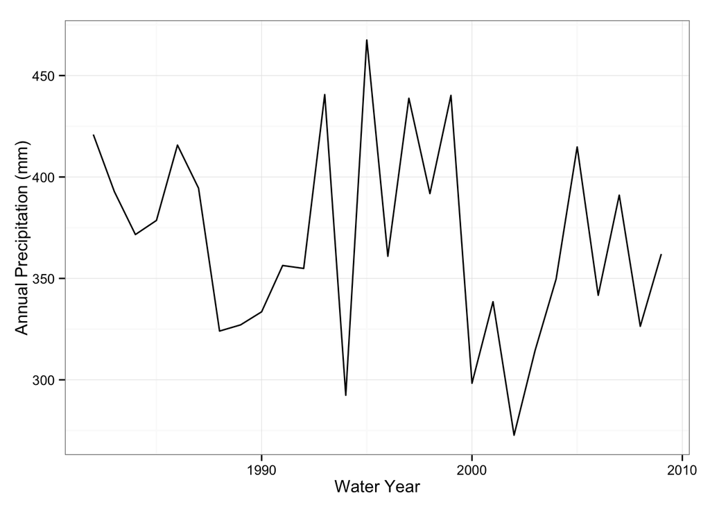

```r
ggplot(clim.wyr, aes(WYEAR, PRCP)) +
  geom_line() +
  labs(x="Water Year", y="Annual Precipitation (mm)")
```

## Wavelet Analysis

The goal of the wavelet analysis is to identify any significant low-frequency signals in the annual precipitation timeseries.

### Scott’s Scripts

This section uses the code written by Scott Steinschneider.

The wavelet analysis and significance test are performed using the `WAVELET_ANALYSIS()` function. This function accepts a numeric array of the annual precipitation time series, a significance level, a type of background noise (white or red), and a flag for generating a plot of the result. It returns the global wave spectrum (GWS), significance levels, and associated period. The periods with powers greater than the corresponding significance levels are significant.

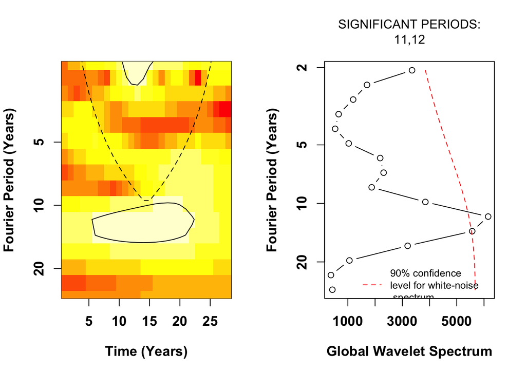

```r
wave.scott <- WAVELET_ANALYSIS(CLIMATE_VARIABLE=clim.wyr$PRCP, siglvl=0.90,
                               background_noise="white", plot_flag=TRUE)
```

The plots show 1) a heat map of the localized power (W(s,t)) and 2) the time-averaged global wavelet spectrum (GWS) as a function of Fourier period. The –o–o– line shows fourier period vs. GWS power, and the red —– line shows period vs. significance power. The “Significant Periods” are those where the GWS power > significance power.

The output of this function is an unnamed list of three vectors corresponding to the 1) GWS power, 2) significance levels, and 3) fourier periods:

```r
wave.scott
```

```
## [[1]]
##  [1] 3357.3 1702.8 1194.6  661.4  533.5 1030.9 2187.8 2313.3 1875.3 3847.0
## [11] 6152.4 5566.6 3196.5 1057.9  377.7  431.8
##
## [[2]]
##  [1] 3846 3979 4124 4281 4449 4626 4808 4989 5161 5315 5442 5539 5606 5647
## [15] 5668 5675
##
## [[3]]
##  [1]  2.066  2.457  2.922  3.475  4.132  4.914  5.844  6.949  8.264  9.828
## [11] 11.688 13.899 16.529 19.656 23.375 27.798
```

If the significance level is lowered from 0.9 to 0.8 then the red line of significance shifts towards the y-axis.

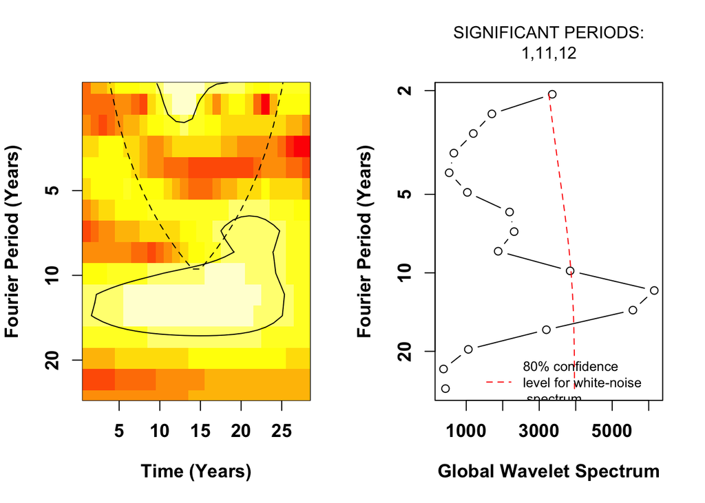

```
## [[1]]
##  [1] 3357.3 1702.8 1194.6  661.4  533.5 1030.9 2187.8 2313.3 1875.3 3847.0
## [11] 6152.4 5566.6 3196.5 1057.9  377.7  431.8
##
## [[2]]
##  [1] 3266 3332 3402 3474 3549 3623 3696 3763 3822 3870 3907 3933 3950 3960
## [15] 3965 3967
##
## [[3]]
##  [1]  2.066  2.457  2.922  3.475  4.132  4.914  5.844  6.949  8.264  9.828
## [11] 11.688 13.899 16.529 19.656 23.375 27.798
```

```r
WAVELET_ANALYSIS(CLIMATE_VARIABLE=clim.wyr$PRCP, siglvl=0.80,
                 background_noise="white", plot_flag=TRUE)
```

### biwavelet Package

The `biwavelet` package contains two functions (`biwavelet::wt()` and `biwavelet::wt.sig()`) that provide identical functionality as Scott’s `WAVELET_ANALYSIS` function. The `biwavelet` package is a translation of the [original matlab code](http://paos.colorado.edu/research/wavelets/software.html) accompanying Torrence and Compo (1998). This same matlab code was used by Scott to create his own R version of the package. Therefore, both Scott’s code and the `biwavelet` package code are essentially identical.

Here is the same analysis for significance level of 0.90 and white background noise using the `biwavelet` package.

```r
library(biwavelet)

bw <- biwavelet::wt(d=cbind(1:length(clim.wyr$PRCP), clim.wyr$PRCP),
                    dt=1, dj=1/4, max.scale=length(clim.wyr$PRCP),
                    sig.level=0.90, lag1=0, sig.test=1)
str(bw)
```

```
## List of 16
##  $ coi       : num [1:28] 7.30e-06 7.30e-01 1.46 2.19 2.92 ...
##  $ wave      : cplx [1:16, 1:28] 0-15.9i 11.7-8.8i 13.2-11.4i ...
##  $ power     : num [1:16, 1:28] 252 214 303 867 1304 ...
##  $ power.corr: num [1:16, 1:28] 3412 2439 2904 6985 8838 ...
##  $ phase     : num [1:16, 1:28] -1.572 -0.65 -0.713 -0.683 -0.239 ...
##  $ period    : num [1:16] 2.07 2.46 2.92 3.47 4.13 ...
##  $ scale     : num [1:16] 2 2.38 2.83 3.36 4 ...
##  $ dt        : num 1
##  $ t         : num [1:28] 1 2 3 4 5 6 7 8 9 10 ...
##  $ xaxis     : num [1:28] 1 2 3 4 5 6 7 8 9 10 ...
##  $ s0        : num 2
##  $ dj        : num 0.25
##  $ sigma2    : num 2465
##  $ mother    : chr "morlet"
##  $ type      : chr "wt"
##  $ signif    : num [1:16, 1:28] 0.0453 0.0383 0.054 0.1539 0.2311 ...
##  - attr(*, "class")= chr "biwavelet"
```

This function returns an object of class `biwavelet` that includes a generic plotting function.

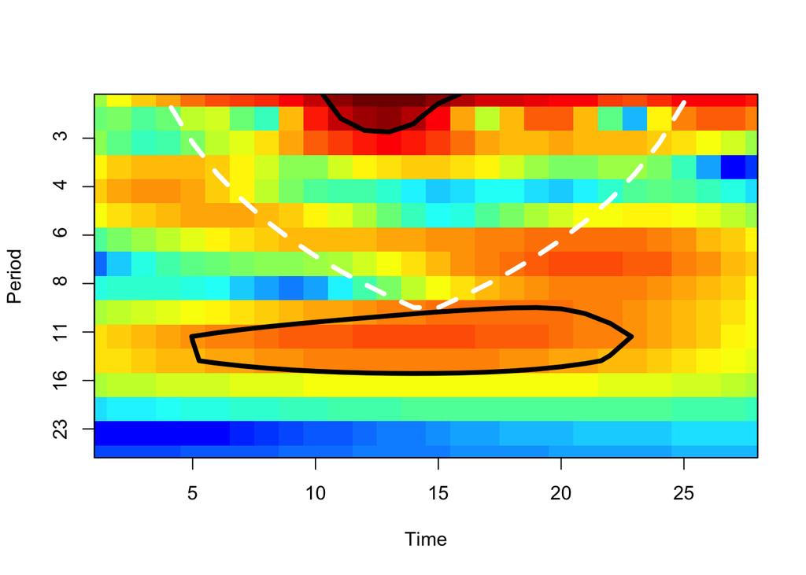

```r
par(mfrow=c(1,1))
plot(bw)
```

The time-averaged global wave spectrum (GWS) is then computed as the row-wise mean the `$power` matrix.

```r
bw$gws <- apply(bw$power, 1, mean)
```

The significance test of the GWS can be computed using the `biwavelet::wt.sig()` function. Note that the degrees of freedom is equal to the number of data points adjusted by scale (to account for edge effects).

```r
bw$gws.sig <- wt.sig(d=clim.wyr$PRCP, dt=bw$dt, scale=bw$scale, sig.test=1,
                     sig.level=0.90, dof=length(clim.wyr$PRCP)-bw$scale,
                     mother='morlet', lag1=0.0)
```

The following tables show identical values for the period, global spectrum power, and significance between Scott’s `WAVELET_ANNUAL()` and the `biwavelet::wt()` function output.

```r
# compare periods
cbind(biwavelet=bw$period, scott=wave.scott[[3]])
```

```
##       biwavelet  scott
##  [1,]     2.066  2.066
##  [2,]     2.457  2.457
##  [3,]     2.922  2.922
##  [4,]     3.475  3.475
##  [5,]     4.132  4.132
##  [6,]     4.914  4.914
##  [7,]     5.844  5.844
##  [8,]     6.949  6.949
##  [9,]     8.264  8.264
## [10,]     9.828  9.828
## [11,]    11.688 11.688
## [12,]    13.899 13.899
## [13,]    16.529 16.529
## [14,]    19.656 19.656
## [15,]    23.375 23.375
## [16,]    27.798 27.798
```

```r
# compare global spectrum (row-wise mean of power for biwavelet::wt())
cbind(biwavelet=bw$gws, scott=wave.scott[[1]])
```

```
##       biwavelet  scott
##  [1,]    3357.3 3357.3
##  [2,]    1702.8 1702.8
##  [3,]    1194.6 1194.6
##  [4,]     661.4  661.4
##  [5,]     533.5  533.5
##  [6,]    1030.9 1030.9
##  [7,]    2187.8 2187.8
##  [8,]    2313.3 2313.3
##  [9,]    1875.3 1875.3
## [10,]    3847.0 3847.0
## [11,]    6152.4 6152.4
## [12,]    5566.6 5566.6
## [13,]    3196.5 3196.5
## [14,]    1057.9 1057.9
## [15,]     377.7  377.7
## [16,]     431.8  431.8
```

```r
# compare signif
cbind(biwavelet=bw$gws.sig$signif, scott=wave.scott[[2]])
```

```
##       biwavelet scott
##  [1,]      3846  3846
##  [2,]      3979  3979
##  [3,]      4124  4124
##  [4,]      4281  4281
##  [5,]      4449  4449
##  [6,]      4626  4626
##  [7,]      4808  4808
##  [8,]      4989  4989
##  [9,]      5161  5161
## [10,]      5315  5315
## [11,]      5442  5442
## [12,]      5539  5539
## [13,]      5606  5606
## [14,]      5647  5647
## [15,]      5668  5668
## [16,]      5675  5675
```

We can also plot the output of `biwavelet::wt()`

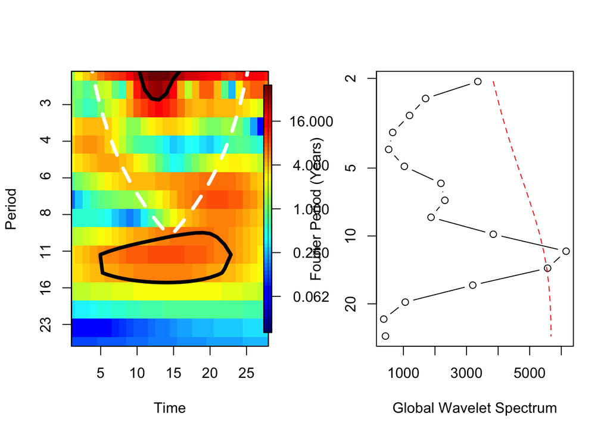

```r
par(mfrow=c(1,2))
plot(bw, plot.cb=TRUE, plot.phase=FALSE)
plot(bw$gws, bw$period, type="b",
     xlab="Global Wavelet Spectrum", ylab="Fourier Period (Years)",
     log="y", ylim=rev(range(bw$period)), xlim=range(c(bw$gws, bw$gws.sig$signif)))
lines(bw$gws.sig$signif, bw$period, lty=2, col='red')
```

Which is effectively identical to the `WAVELET_ANALYSIS()` output plot.

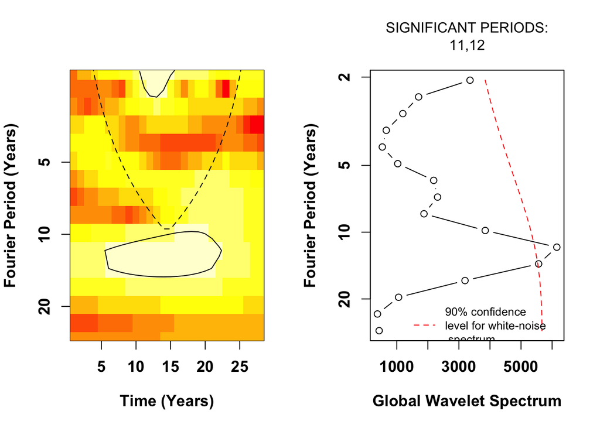

```
## [[1]]
##  [1] 3357.3 1702.8 1194.6  661.4  533.5 1030.9 2187.8 2313.3 1875.3 3847.0
## [11] 6152.4 5566.6 3196.5 1057.9  377.7  431.8
##
## [[2]]
##  [1] 3846 3979 4124 4281 4449 4626 4808 4989 5161 5315 5442 5539 5606 5647
## [15] 5668 5675
##
## [[3]]
##  [1]  2.066  2.457  2.922  3.475  4.132  4.914  5.844  6.949  8.264  9.828
## [11] 11.688 13.899 16.529 19.656 23.375 27.798
```

```r
WAVELET_ANALYSIS(CLIMATE_VARIABLE=clim.wyr$PRCP, siglvl=0.90,
                 background_noise="white", plot_flag=TRUE)
```

### weatherGen Package

The `weatherGen` package provides a `wavelet_analysis()` function that uses the biwavelet `wt()` and `wt.sig()` functions to provide similar functionality as Scott’s `WAVELET_ANALYSIS()` function, but with fewer lines of code.

```r
wave.wgen <- wavelet_analysis(x=clim.wyr$PRCP, sig.level=0.90, noise.type="white")
str(wave.wgen)
```

```
## List of 18
##  $ coi       : num [1:28] 7.30e-06 7.30e-01 1.46 2.19 2.92 ...
##  $ wave      : cplx [1:16, 1:28] 0-15.9i 11.7-8.8i 13.2-11.4i ...
##  $ power     : num [1:16, 1:28] 252 214 303 867 1304 ...
##  $ power.corr: num [1:16, 1:28] 3412 2439 2904 6985 8838 ...
##  $ phase     : num [1:16, 1:28] -1.572 -0.65 -0.713 -0.683 -0.239 ...
##  $ period    : num [1:16] 2.07 2.46 2.92 3.47 4.13 ...
##  $ scale     : num [1:16] 2 2.38 2.83 3.36 4 ...
##  $ dt        : num 1
##  $ t         : num [1:28] 1 2 3 4 5 6 7 8 9 10 ...
##  $ xaxis     : num [1:28] 1 2 3 4 5 6 7 8 9 10 ...
##  $ s0        : num 2
##  $ dj        : num 0.25
##  $ sigma2    : num 2465
##  $ mother    : chr "morlet"
##  $ type      : chr "wt"
##  $ signif    : num [1:16, 1:28] 0.0444 0.0377 0.0534 0.1527 0.2298 ...
##  $ gws       : num [1:16] 3357 1703 1195 661 533 ...
##  $ gws.sig   :List of 2
##   ..$ signif   : num [1:16] 3846 3979 4124 4281 4449 ...
##   ..$ fft.theor: num [1:16] 2465 2465 2465 2465 2465 ...
##  - attr(*, "class")= chr "biwavelet"
```

And we can plot this same as with the `biwavelet` output as before.

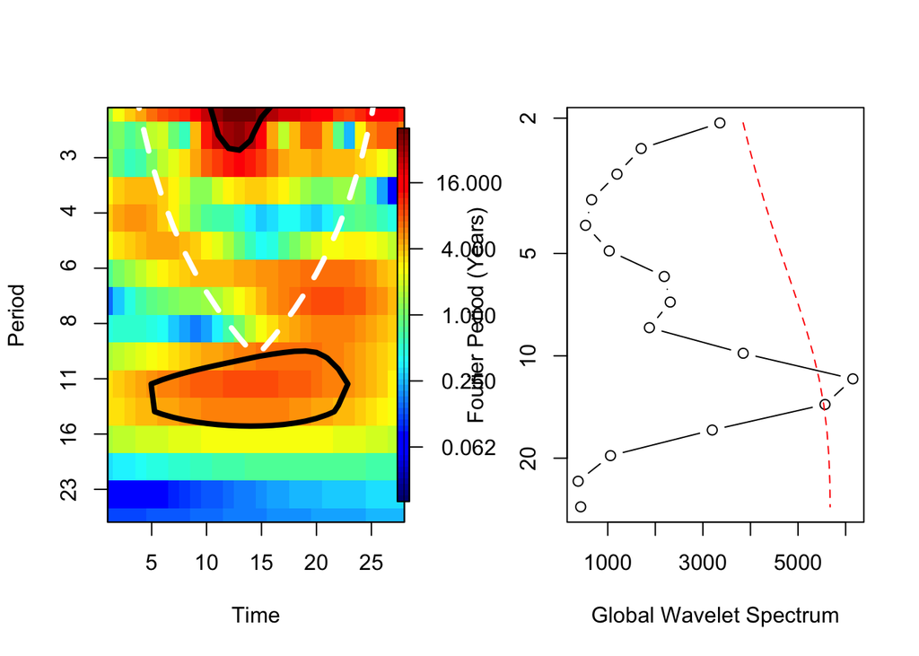

```r
par(mfrow=c(1,2))
plot(wave.wgen, plot.cb=TRUE, plot.phase=FALSE)
plot(wave.wgen$gws, wave.wgen$period, type="b",
     xlab="Global Wavelet Spectrum", ylab="Fourier Period (Years)",
     log="y", ylim=rev(range(wave.wgen$period)),
     xlim=range(c(wave.wgen$gws, wave.wgen$gws.sig$signif)))
lines(wave.wgen$gws.sig$signif, wave.wgen$period, lty=2, col='red')
```